NetReserve by NetSimR

# Reserving Report

Generated 20 November 2026, 13:55

## Key results

Simulated motor: paid and incurred claims, premiums: 12 origins, 12 development periods.

Latest

69,294,594

Selected ultimate

84,313,138

Loss ratio 70.0%

Selected IBNR

15,018,544

Chain ladder IBNR

15,018,544

Mack standard error 967,470, CV 6.4%

One-year standard error

734,605

Merz-Wüthrich

Bootstrap 99.5%

17,456,496

Mean 15,032,506

## Data and settings

Data

**Source**

Simulated motor: paid and incurred claims, premiums

**Origins**

2014 to 2025

**Development periods**

12

**Premiums**

120,431,000

**Incurred claims**

Yes

Development

**Average**

Volume-weighted

**Calendar periods**

All

**Link ratios left out**

0

**Tail**

None

**Single link ratio sigma**

Log-linear

Ultimates

**Methods**

12 Chain ladder

**Cape Cod decay**

1

**Cape Cod loss ratio**

69.7%

## Development factors

### Factors

| Factor | Selected | To ultimate | Link ratios used |
| --- | --- | --- | --- |
| 1-2 | 1.8866 | 3.3372 | 11 |
| 2-3 | 1.2799 | 1.7689 | 10 |
| 3-4 | 1.1411 | 1.3821 | 9 |
| 4-5 | 1.0754 | 1.2112 | 8 |
| 5-6 | 1.0508 | 1.1263 | 7 |
| 6-7 | 1.0280 | 1.0718 | 6 |
| 7-8 | 1.0170 | 1.0426 | 5 |
| 8-9 | 1.0111 | 1.0252 | 4 |
| 9-10 | 1.0114 | 1.0139 | 3 |
| 10-11 | 1.0011 | 1.0025 | 2 |
| 11-12 | 1.0014 | 1.0014 | 1 |
| Tail | 1.0000 | 1.0000 |  |

Averages: volume-weighted. Sigma of 11-12 (a single link ratio) extrapolated log-linearly.

### Tail factors compared

| Tail | Tail factor | Chain ladder IBNR |
| --- | --- | --- |
| No tail | 1.0000 | 15,018,544 |
| Exponential curve, from factor 1 | 1.0017 | 15,159,683 |
| Inverse power curve, from factor 1 | 1.0225 | 16,914,234 |
| Clark log-logistic | 1.1361 | 26,489,498 |
| Clark Weibull | 1.0141 | 16,204,327 |

The tail each curve gives beyond the last development period, with the chain ladder's IBNR.

### Development

Each line is an origin, from the oldest (lightest) to the latest (darkest).

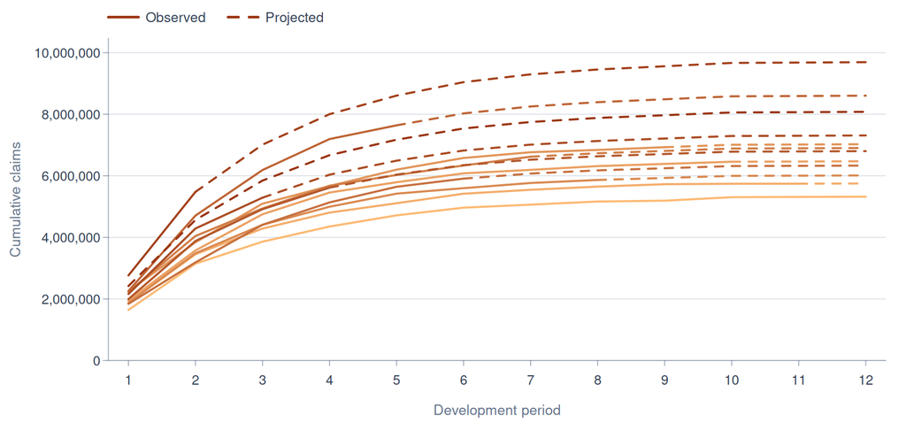

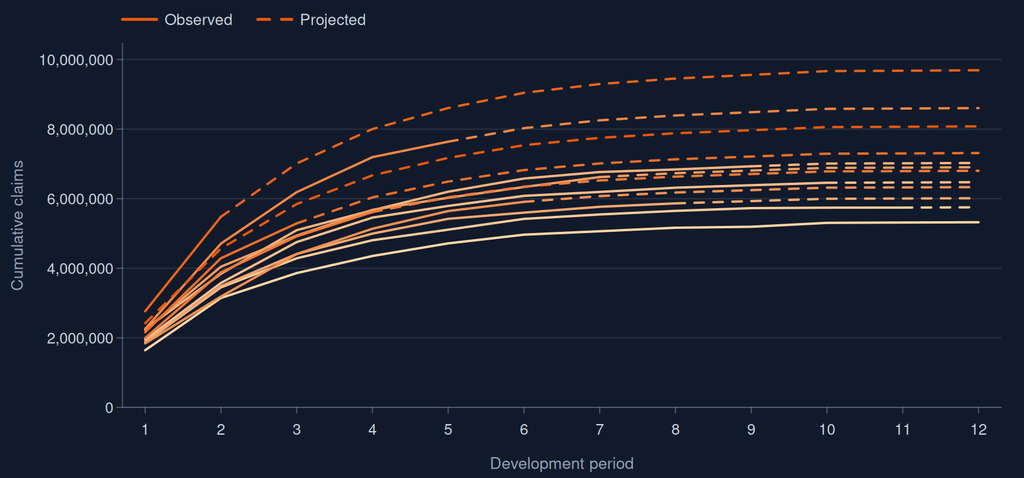

### Link ratios

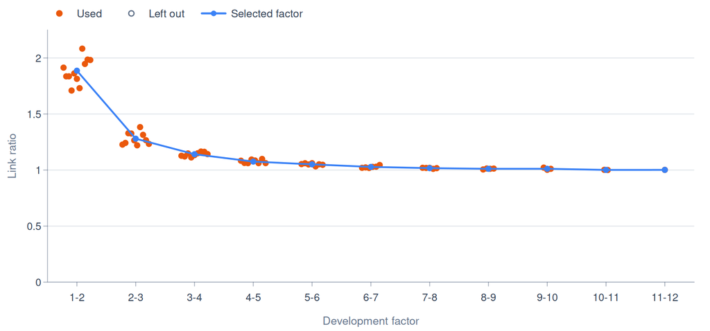

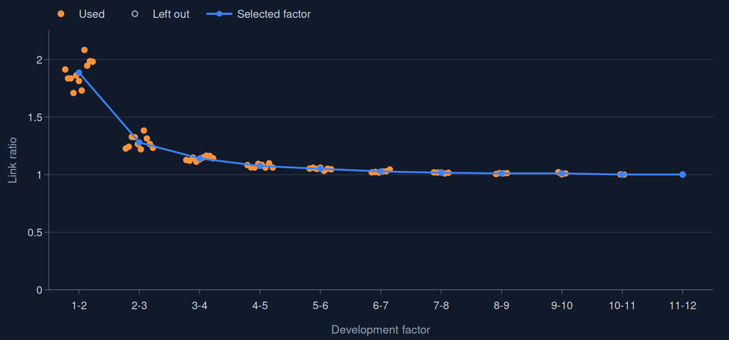

## Ultimates

### By origin

| Origin | Latest | Developed | Chain ladder | BF | Benktander | Cape Cod | Selected | Ultimate | IBNR | Loss ratio |
| --- | --- | --- | --- | --- | --- | --- | --- | --- | --- | --- |
| 2014 | 5,322,407 | 100.0% | 5,322,407 | 5,322,407 | 5,322,407 | 5,322,407 | Chain ladder | 5,322,407 | 0 | 65.3% |
| 2015 | 5,743,751 | 99.9% | 5,752,006 | 5,752,118 | 5,752,006 | 5,752,083 | Chain ladder | 5,752,006 | 8,255 | 69.1% |
| 2016 | 6,457,627 | 99.7% | 6,473,957 | 6,473,264 | 6,473,955 | 6,473,200 | Chain ladder | 6,473,957 | 16,330 | 73.1% |
| 2017 | 6,930,336 | 98.6% | 7,026,956 | 7,020,320 | 7,026,865 | 7,019,949 | Chain ladder | 7,026,956 | 96,620 | 75.2% |
| 2018 | 5,865,110 | 97.5% | 6,013,065 | 6,028,118 | 6,013,436 | 6,027,446 | Chain ladder | 6,013,065 | 147,955 | 63.5% |
| 2019 | 6,621,118 | 95.9% | 6,903,429 | 6,898,390 | 6,903,223 | 6,897,247 | Chain ladder | 6,903,429 | 282,311 | 71.3% |
| 2020 | 5,908,704 | 93.3% | 6,332,839 | 6,388,960 | 6,336,597 | 6,386,981 | Chain ladder | 6,332,839 | 424,135 | 61.8% |
| 2021 | 7,639,503 | 88.8% | 8,604,127 | 8,463,681 | 8,588,381 | 8,460,284 | Chain ladder | 8,604,127 | 964,624 | 81.9% |
| 2022 | 5,615,887 | 82.6% | 6,801,772 | 6,938,362 | 6,825,587 | 6,932,912 | Chain ladder | 6,801,772 | 1,185,885 | 62.8% |
| 2023 | 5,290,187 | 72.4% | 7,311,556 | 7,540,672 | 7,374,898 | 7,531,398 | Chain ladder | 7,311,556 | 2,021,369 | 62.9% |
| 2024 | 5,479,114 | 56.5% | 9,692,085 | 9,039,765 | 9,408,533 | 9,025,090 | Chain ladder | 9,692,085 | 4,212,971 | 82.8% |
| 2025 | 2,420,850 | 30.0% | 8,078,939 | 8,148,877 | 8,127,920 | 8,125,270 | Chain ladder | 8,078,939 | 5,658,089 | 69.1% |
| Total | 69,294,594 | 82.2% | 84,313,138 | 84,014,934 | 84,153,808 | 83,954,267 |  | 84,313,138 | 15,018,544 | 70.0% |

BF: Bornhuetter-Ferguson. The selected method of each origin gives its ultimate. The Cape Cod loss ratio is 69.7%.

### Ultimates by origin

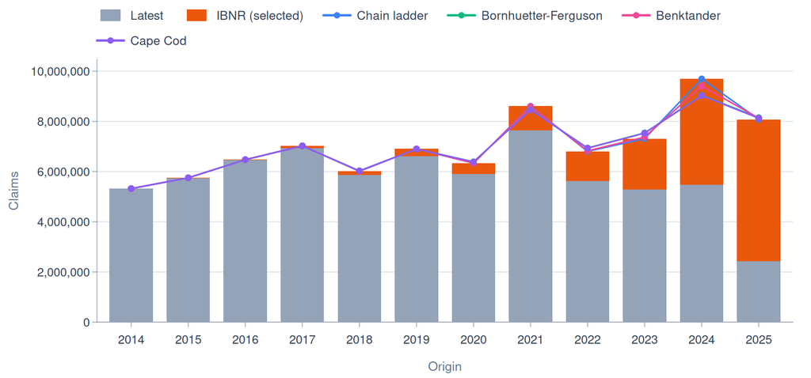

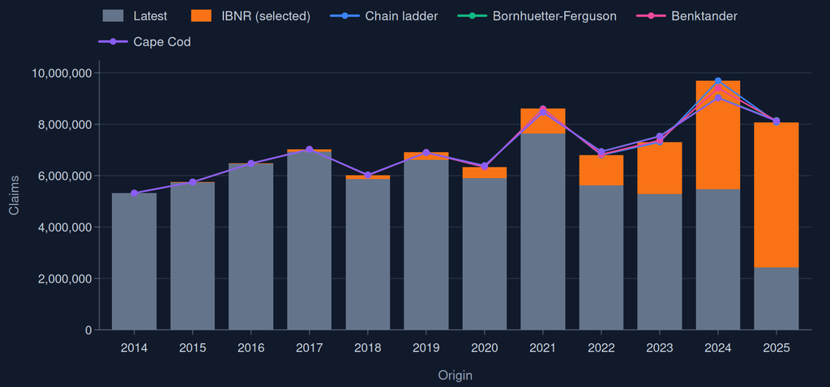

## Uncertainty

### Mack's standard errors

| Origin | IBNR | Standard error | CV | Process | Parameter |
| --- | --- | --- | --- | --- | --- |
| 2014 | 0 | 0 | — | 0 | 0 |
| 2015 | 8,255 | 11,127 | 134.8% | 7,714 | 8,019 |
| 2016 | 16,330 | 14,387 | 88.1% | 10,195 | 10,152 |
| 2017 | 96,620 | 72,113 | 74.6% | 60,489 | 39,261 |
| 2018 | 147,955 | 69,857 | 47.2% | 60,244 | 35,364 |
| 2019 | 282,311 | 81,161 | 28.7% | 69,257 | 42,315 |
| 2020 | 424,135 | 100,910 | 23.8% | 89,768 | 46,094 |
| 2021 | 964,624 | 142,015 | 14.7% | 124,003 | 69,221 |
| 2022 | 1,185,885 | 162,191 | 13.7% | 148,426 | 65,387 |
| 2023 | 2,021,369 | 206,568 | 10.2% | 190,228 | 80,523 |
| 2024 | 4,212,971 | 431,007 | 10.2% | 397,873 | 165,723 |
| 2025 | 5,658,089 | 621,112 | 11.0% | 586,690 | 203,902 |
| Total | 15,018,544 | 967,470 | 6.4% | 772,274 | 582,743 |

Of the chain ladder: the process and parameter parts of the standard error.

### One-year view

| Origin | One-year standard error | Until ultimate |
| --- | --- | --- |
| 2014 | 0 | 0 |
| 2015 | 11,127 | 11,127 |
| 2016 | 10,044 | 14,387 |
| 2017 | 70,890 | 72,113 |
| 2018 | 31,001 | 69,857 |
| 2019 | 35,390 | 81,161 |
| 2020 | 68,575 | 100,910 |
| 2021 | 79,057 | 142,015 |
| 2022 | 108,811 | 162,191 |
| 2023 | 122,512 | 206,568 |
| 2024 | 358,317 | 431,007 |
| 2025 | 487,383 | 621,112 |
| Total | 734,605 | 967,470 |

Merz and Wüthrich: how much the ultimate can move over the next year.

### Bootstrap

| Origin | Mean IBNR | Standard deviation | 75% | 90% | 95% | 99% | 99.5% |
| --- | --- | --- | --- | --- | --- | --- | --- |
| 2014 | 0 | 0 | 0 | 0 | 0 | 0 | 0 |
| 2015 | 7,990 | 18,515 | 14,283 | 30,001 | 41,824 | 71,217 | 84,036 |
| 2016 | 15,822 | 25,409 | 28,686 | 47,709 | 61,924 | 94,181 | 105,556 |
| 2017 | 96,432 | 50,780 | 126,442 | 164,202 | 187,452 | 237,917 | 255,372 |
| 2018 | 147,423 | 58,341 | 182,090 | 223,601 | 251,495 | 309,859 | 330,504 |
| 2019 | 281,389 | 82,916 | 331,649 | 389,565 | 426,012 | 505,065 | 531,298 |
| 2020 | 424,077 | 98,826 | 487,506 | 555,390 | 595,071 | 675,942 | 706,148 |
| 2021 | 963,224 | 153,590 | 1,061,691 | 1,160,931 | 1,223,248 | 1,364,962 | 1,429,483 |
| 2022 | 1,191,325 | 166,719 | 1,300,250 | 1,409,018 | 1,474,707 | 1,607,183 | 1,672,024 |
| 2023 | 2,021,724 | 232,963 | 2,174,187 | 2,325,544 | 2,409,737 | 2,583,462 | 2,630,758 |
| 2024 | 4,220,049 | 382,967 | 4,478,046 | 4,716,510 | 4,867,494 | 5,140,383 | 5,249,812 |
| 2025 | 5,663,051 | 595,749 | 6,069,517 | 6,436,469 | 6,639,987 | 7,064,828 | 7,197,376 |
| Total | 15,032,506 | 926,951 | 15,652,033 | 16,230,087 | 16,535,075 | 17,203,400 | 17,456,496 |

Bootstrap chain ladder (gamma process, 5,000 simulations), 5,000 simulations.

### Distribution of the total IBNR

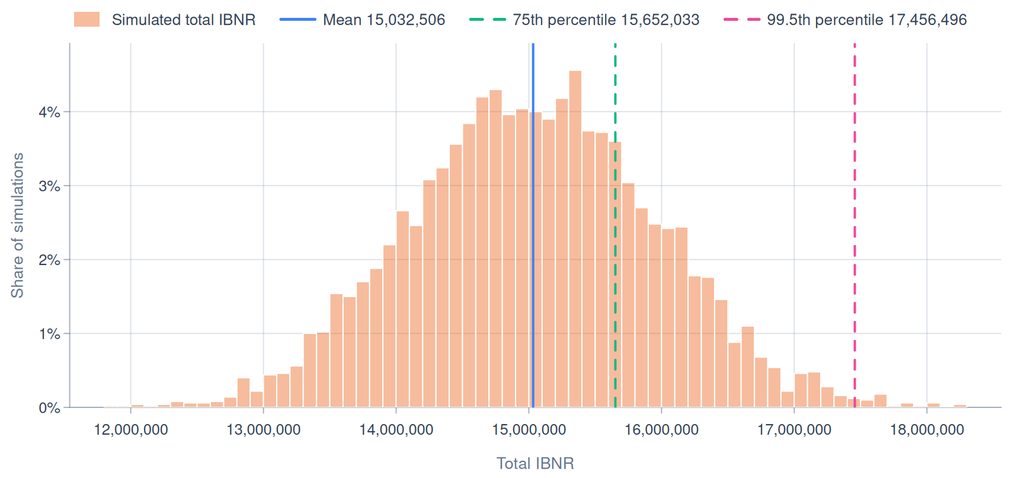

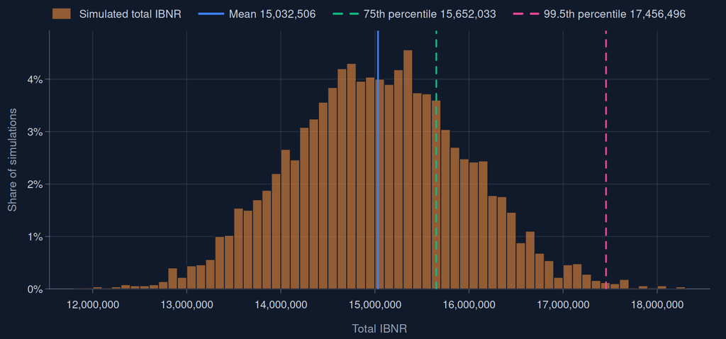

## IFRS 17 and Solvency II

Best estimate

14,093,274

Discounted from 15,018,544; mean term 2.06 years

Risk adjustment

581,359

Percentile; confidence level 75.0%

Liability for incurred claims

14,674,633

Reserve risk (Solvency II)

3,805,184

Segment 1, standard deviation 9.0%

### Discounted reserves

| Origin | Reserve | Discounted | Discount |
| --- | --- | --- | --- |
| 2014 | 0 | 0 | 0 |
| 2015 | 8,255 | 8,133 | 121 |
| 2016 | 16,330 | 15,817 | 513 |
| 2017 | 96,620 | 94,374 | 2,246 |
| 2018 | 147,955 | 142,621 | 5,334 |
| 2019 | 282,311 | 269,416 | 12,895 |
| 2020 | 424,135 | 402,032 | 22,103 |
| 2021 | 964,624 | 911,394 | 53,230 |
| 2022 | 1,185,885 | 1,114,566 | 71,320 |
| 2023 | 2,021,369 | 1,895,409 | 125,960 |
| 2024 | 4,212,971 | 3,943,098 | 269,872 |
| 2025 | 5,658,089 | 5,296,413 | 361,676 |
| Total | 15,018,544 | 14,093,274 | 925,270 |

Spot rates 3.00, 3.10, 3.20, 3.30, 3.40% for 1, 2, 3, ... years; payments mid-period of each period of 1 years.

### Cash flows

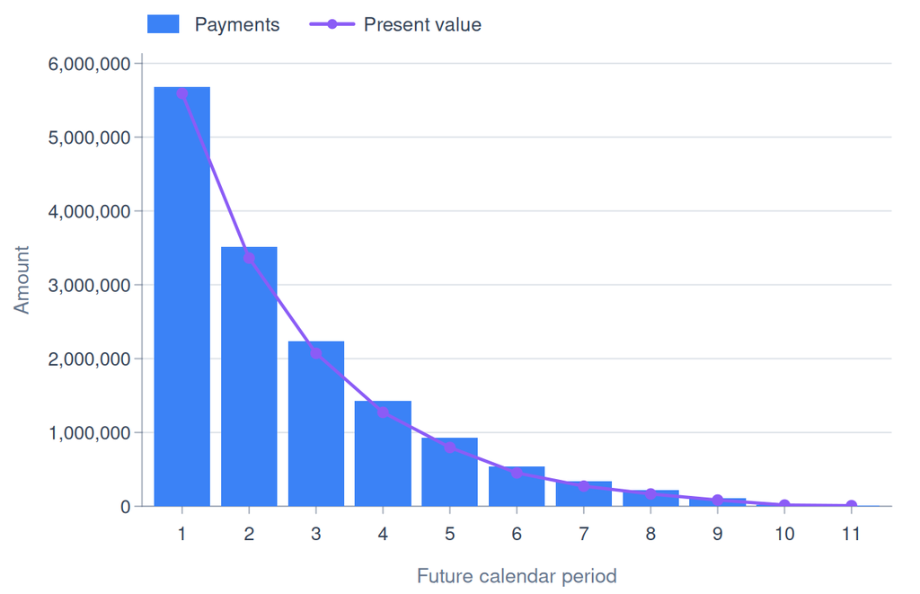

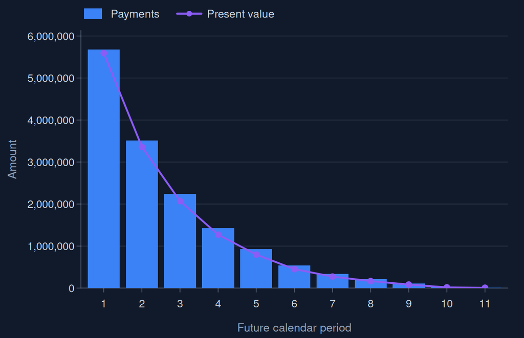

## More methods

### Actual vs expected, latest period

| Origin | Expected | Actual | Actual / expected | z |
| --- | --- | --- | --- | --- |
| 2014 | — | 7,638 | — | — |
| 2015 | 10,552 | 2,292 | 22% | -0.33 |
| 2016 | 73,861 | 70,738 | 96% | -0.031 |
| 2017 | 70,494 | 90,235 | 128% | 0.63 |
| 2018 | 97,916 | 98,054 | 100% | 0.0047 |
| 2019 | 153,218 | 285,080 | 186% | 3.9 |
| 2020 | 290,745 | 264,490 | 91% | -0.42 |
| 2021 | 561,657 | 445,225 | 79% | -1.1 |
| 2022 | 693,113 | 699,512 | 101% | 0.063 |
| 2023 | 1,226,081 | 1,001,064 | 82% | -1 |
| 2024 | 2,414,826 | 2,714,510 | 112% | 1 |
| 2025 | — | — | — | — |
| Total | 5,592,464 | 5,671,200 | 101% | 0.19 |

z beyond about 2 either way is worth a look.

### Other methods

| Method | IBNR | Standard error |
| --- | --- | --- |
| Chain ladder | 15,018,544 | 967,470 |
| Clark Clark LDF method, log-logistic curve | 29,458,751 | 2,580,277 |
| Chain ladder with claims inflation | 15,018,544 | — |

## Paid and incurred

### Munich chain ladder

| Origin | CL paid | CL incurred | Munich paid | Munich incurred |
| --- | --- | --- | --- | --- |
| 2014 | 5,322,407 | 5,328,268 | 5,322,407 | 5,328,268 |
| 2015 | 5,752,006 | 5,759,629 | 5,753,192 | 5,758,214 |
| 2016 | 6,473,957 | 6,470,979 | 6,457,649 | 6,490,285 |
| 2017 | 7,026,956 | 7,028,262 | 7,020,339 | 7,035,382 |
| 2018 | 6,013,065 | 5,999,685 | 6,010,117 | 6,000,869 |
| 2019 | 6,903,429 | 6,925,275 | 6,901,780 | 6,926,455 |
| 2020 | 6,332,839 | 6,407,393 | 6,355,537 | 6,388,312 |
| 2021 | 8,604,127 | 8,596,618 | 8,589,386 | 8,610,707 |
| 2022 | 6,801,772 | 6,882,265 | 6,830,303 | 6,855,349 |
| 2023 | 7,311,556 | 7,441,385 | 7,361,421 | 7,388,955 |
| 2024 | 9,692,085 | 9,563,432 | 9,613,093 | 9,637,418 |
| 2025 | 8,078,939 | 9,248,129 | 8,668,084 | 8,715,947 |
| Total | 84,313,138 | 85,651,321 | 84,883,308 | 85,136,161 |

The ultimates of paid and incurred claims projected together.

## How to read this report

- The IBNR is the ultimate less the latest claims: for paid claims it includes the case reserves.
- Mack's standard error measures the uncertainty of the chain ladder until the claims are all paid; the one-year standard error, the part that can emerge over the next year.
- The bootstrap simulates the reserves, so its percentiles, such as 99.5%, give the reserve risk directly.
- Figures follow the choices of the tool when the report was made: the factors, the tail and each origin's method.